# Tutorial 4 - Data Wrangle

Author: Matthew J. Cossley

Last update: 14 March, 2022

## Learning objectives

- Get lots of hands-on practice with `R` and `data.table` and `ggplot`.
- Do some almost real-world data wrangling.
- Understand how to use the `list.files` function.
- Understand the basics of `for` loops.
- Understand how to create a `list` of `data.table` objects and how to convert that `list` into a single combined `data.table` using the `rbindlist` function.

## Get some experiment data

- If you haven’t already participated in the following short demo experiment, please do so at the following address: `https://run.pavlovia.org/demos/stroop/`
- Be sure to enter your name or some other ID that you will remember and can be easily searched for.
- Download your data in a `.csv` file by taking the following steps:
- Go here: `https://gitlab.pavlovia.org/demos/stroop`
- Read about the experiment you just participated in by scrolling to the bottom and reading the `README.md` file.
- Click the `data` folder to land at the following address: `https://gitlab.pavlovia.org/demos/stroop/tree/master/data`
- In previous tutorials, I instructed you to find and download only your data. In this tutorial, please download a small batch of data (somewhere around 5 files should be plenty but you can download the all the `.csv` files if you like). It doesn’t matter which files they are so long as they are `.csv` data files all with identical format.

## Get ready to analyse your data

- If you haven’t done so already, create a new folder on your computer named `cogs2020`
- Open Rstudio and click `File > New File > R Script`
- In Rstudio click `File > Save`
- In the prompt that comes up, name your file `tutorial_4_notes.R`, and save it in your `cogs2020` folder.
- Move the batch `.csv` files you just downloaded into your `cogs2020` folder.

## Analyse your data using `data.table` and `ggplot`

- The big challenge that we will begin working on today is wrangling all of those individual `.csv` files into one big `data.table`. Do this is a critical step towards using `R` to do actual inferential statistics on data from real world experiments.

```r
# Load the `data.table` and `ggplot2` libraries and `rm` to
# be sure your are starting with a clean work space.
library(data.table)
library(ggplot2)

rm(list = ls())

# Use the `list.files` function to save a list of file paths
# corresponding to your just downloaded data files. Here, I
# have written `'data/stroop'` because that is where I put
# the data that I downloaded. You will need change this to
# something appropriate to where you put these files.
file_list <- list.files('data/stroop', full.names=T)

# create an empty list with as many elements as we have data
# files
d_list <- vector("list", length(file_list))

# iterate through our list of data files and read each into
# a data.table, which we then store in d_list
for(i in 1:length(file_list)) {
  z <- fread(file_list[[i]])
  z[, subject := i]
  d_list[[i]] <- z
}

# bind our list of data.tables into one big data.table
d <- rbindlist(d_list)
```

```r
d[, .(text, letterColor, congruent, corrAns, resp.keys, resp.rt, subject)]
```

```
##       text letterColor congruent corrAns resp.keys resp.rt subject
##   1: green       green         1    down      left  0.7099       1
##   2: green        blue         0   right      left  0.4665       1
##   3:  blue         red         0    left      left  0.1611       1
##   4:   red         red         1    left      left  0.0462       1
##   5:   red       green         0    down      left  0.1017       1
##  ---
## 114: green       green         1    down      left  1.0210       7
## 115:   red         red         1    left     right  1.2350       7
## 116:  blue         red         0    left     right  1.1620       7
## 117:  blue        blue         1   right      down  0.7480       7
## 118:   red       green         0    down      left  0.6630       7
```

- The classic Stroop finding is that people are slower and less accurate on incongruent trials (i.e., trials on which stimulus text and stimulus colour do not match) than they are on congruent trials. Lets see if our data pan out that way.

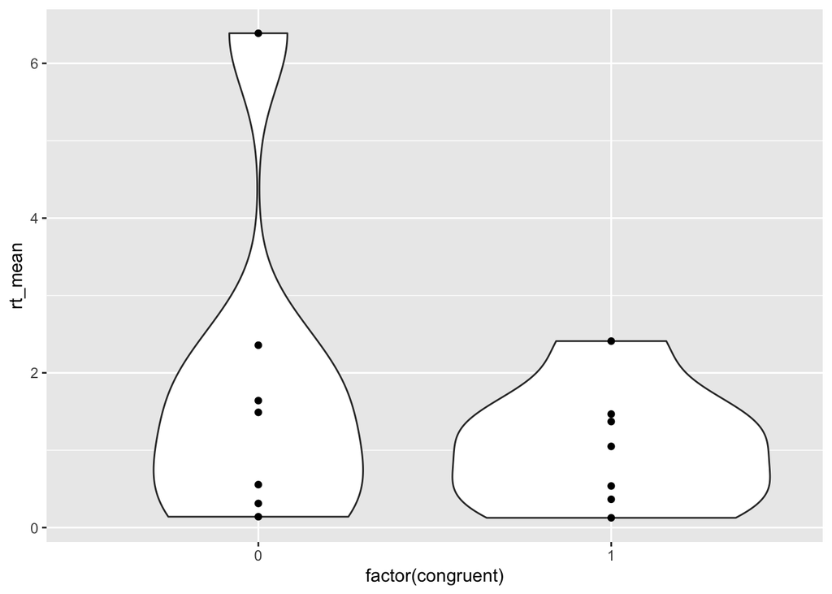

```r
# first create a column to indicate response accuracy
d[, acc := corrAns == resp.keys]

# report what your overall accuracy and rt was grouped by
# subject and grouped by congruent
dd <- d[,
        .(acc_mean = mean(acc), rt_mean = mean(resp.rt)),
        .(subject, congruent)]

# inspect reaction time
ggplot(dd, aes(x=factor(congruent), y=rt_mean)) +
  geom_violin() +
  geom_point()
```

- Visualise this data in as many other ways as you can.

## Work on problem set 4

- Problem set 4